# Lathyrus ms2: selection on reaction norms for flowering time

Variation in selection among years using BLUPs - glmmTMB models

Alicia Valdés

# Read data and check ns

```r
datadef_BLUPs<-read.csv("data/datadef_BLUPs.csv")
head(datadef_BLUPs)
```

|  | year | id_nr | id | fcode | FFD | n_fl | n_fr | totseed | intactseed | shoot_vol | period | n_years_fl_fitness | n_years_study | mean_4 | cmean_4 | intercept | slope |
| --- | --- | --- | --- | --- | --- | --- | --- | --- | --- | --- | --- | --- | --- | --- | --- | --- | --- |
| 1 | 1989 | 1 | old_1 | 1 | NA | 6 | 3 | 8 | 6 | 1418.6000 | old | 5 | 8 | 5.236667 | -0.228207783 | -0.7399266 | -0.2018749 |
| 2 | 1990 | 1 | old_1 | 0 | NA | 0 | 0 | 0 | 0 | 523.2000 | old | 5 | 8 | 7.195000 | 1.730125551 | -0.7399266 | -0.2018749 |
| 3 | 1991 | 1 | old_1 | 1 | 59.91181 | 23 | 3 | 12 | 12 | 1915.4000 | old | 5 | 8 | 5.245000 | -0.219874449 | -0.7399266 | -0.2018749 |
| 4 | 1992 | 1 | old_1 | 1 | 55.66944 | 19 | 2 | 6 | 1 | 1460.1917 | old | 5 | 8 | 3.828333 | -1.636541116 | -0.7399266 | -0.2018749 |
| 5 | 1993 | 1 | old_1 | 1 | NA | NA | 0 | 0 | 0 | 879.6493 | old | 5 | 8 | 5.461667 | -0.003207783 | -0.7399266 | -0.2018749 |
| 6 | 1994 | 1 | old_1 | 1 | 59.18403 | 14 | 1 | 3 | 3 | 1338.6727 | old | 5 | 8 | 6.418333 | 0.953458884 | -0.7399266 | -0.2018749 |

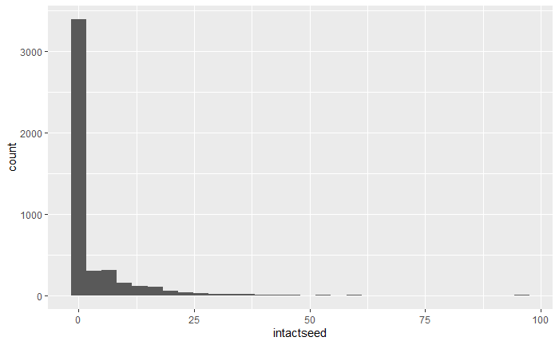

```r
ggplot(datadef_BLUPs,aes(x=intactseed))+geom_histogram()
```

# Models with glmmTMB

## Temp*slope

Does selection on plasticity depend on temperature?

Trying different distributions and models with and without zero-inflation

```r
# Models without zero-inflation
modelBLUP_1_1<-glmmTMB(round(intactseed)~slope*cmean_4+(1|id),family="poisson",
                data=datadef_BLUPs)
modelBLUP_1_2<-glmmTMB(round(intactseed)~slope*cmean_4+(1|id),family="nbinom2",
                data=datadef_BLUPs)
# Models with zero-inflation
modelBLUP_1_3<-glmmTMB(formula=round(intactseed)~slope*cmean_4+(1|id),
                ziformula=~.,family="poisson",data=datadef_BLUPs)
modelBLUP_1_4<-glmmTMB(formula=round(intactseed)~slope*cmean_4+(1|id),
                ziformula=~.,family="nbinom2",data=datadef_BLUPs)
```

```r
AIC(modelBLUP_1_1,modelBLUP_1_2,modelBLUP_1_3,modelBLUP_1_4)
anova(modelBLUP_1_1,modelBLUP_1_2,modelBLUP_1_3,modelBLUP_1_4)
```

modelBLUP_1_4 with a zero-inflated negative binomial is the best model.

```r
summary(modelBLUP_1_4)
```

Predicted effects:

```r
plot(ggpredict(modelBLUP_1_4,terms=c("slope","cmean_4"),type="zero_inflated"))
# Predicted values are conditioned on the fixed effects
# and the zero-inflation component
plot(ggpredict(modelBLUP_1_4,terms=c("slope","cmean_4"),type="zi_prob"))
# Predicted zero-inflation probability
```

Selection for plasticity (more negative slopes) increases with temperature, but this is only driven by the zero-inflated part of the model, i.e. the probability of fitness being zero decreases more with higher plasticity (more negative slopes) with warm temperatures.

## Temp*slope+volume

Does selection on plasticity depend on temperature when considering also plant size?

Trying different distributions and models with and without zero-inflation

```r
# Models without zero-inflation
modelBLUP_2_1<-glmmTMB(round(intactseed)~slope*cmean_4+cn_shoot_vol_mean_sqrt+
                         (1|id),family="poisson",data=datadef_BLUPs)
modelBLUP_2_2<-glmmTMB(round(intactseed)~slope*cmean_4+cn_shoot_vol_mean_sqrt+
                         (1|id),family="nbinom2",data=datadef_BLUPs)
# Models with zero-inflation
modelBLUP_2_3<-glmmTMB(formula=round(intactseed)~slope*cmean_4+
                         cn_shoot_vol_mean_sqrt+(1|id),ziformula=~.,
                       family="poisson",data=datadef_BLUPs)
modelBLUP_2_4<-glmmTMB(formula=round(intactseed)~slope*cmean_4+
                         cn_shoot_vol_mean_sqrt+(1|id),ziformula=~.,
                       family="nbinom2",data=datadef_BLUPs)
```

```r
AIC(modelBLUP_2_1,modelBLUP_2_2,modelBLUP_2_3,modelBLUP_2_4)
anova(modelBLUP_2_1,modelBLUP_2_2,modelBLUP_2_3,modelBLUP_2_4)
```

modelBLUP_2_4 with a zero-inflated negative binomial is the best model.

```r
summary(modelBLUP_2_4)
```

Predicted effects:

```r
plot(ggpredict(modelBLUP_2_4,terms=c("slope","cmean_4"),type="zero_inflated"))
# Predicted values are conditioned on the fixed effects
# and the zero-inflation component
plot(ggpredict(modelBLUP_2_4,terms=c("slope","cmean_4"),type="zi_prob"))
# Predicted zero-inflation probability
```

The interaction slope:temperature in the zero-inflation part of the model is not significant (p=0.053) when including volume.

## Volume*slope

Does selection on plasticity depend on plant size?

Trying different distributions and models with and without zero-inflation

```r
AIC(modelBLUP_3_1,modelBLUP_3_2,modelBLUP_3_3,modelBLUP_3_4)
```

|  | df | AIC |
| --- | --- | --- |
| modelBLUP_3_1 | 6 | 36268.42 |
| modelBLUP_3_2 | 7 | 13837.36 |
| modelBLUP_3_3 | 12 | 16401.26 |
| modelBLUP_3_4 | 13 | 13190.45 |

```r
anova(modelBLUP_3_1,modelBLUP_3_2,modelBLUP_3_3,modelBLUP_3_4)
```

[output not shown]

```r
summary(modelBLUP_3_4)
```

[output not shown]

modelBLUP_3_4 with a zero-inflated negative binomial is the best model.

```r
summary(modelBLUP_3_4)
```

Predicted effects:

```r
plot(ggpredict(modelBLUP_3_4,terms=c("slope","cn_shoot_vol_mean_sqrt"),
               type="zero_inflated"))
# Predicted values are conditioned on the fixed effects
# and the zero-inflation component
plot(ggpredict(modelBLUP_3_4,terms=c("slope","cn_shoot_vol_mean_sqrt"),
               type="zi_prob"))
# Predicted zero-inflation probability
```

Selection for plasticity (more negative slopes) decreases with size, but this is only driven by the zero-inflated part of the model, i.e. the probability of fitness being zero decreases more with higher plasticity (more negative slopes) with lower sizes.

## Temp*slope+volume*slope

Does selection on plasticity depend on temperature AND on plant size?

Trying different distributions and models with and without zero-inflation

```r
# Models without zero-inflation
modelBLUP_4_1<-glmmTMB(round(intactseed)~slope*cmean_4+
                         slope*cn_shoot_vol_mean_sqrt+cmean_4+
                         (1|id),family="poisson",data=datadef_BLUPs)
modelBLUP_4_2<-glmmTMB(round(intactseed)~slope*cmean_4+
                         slope*cn_shoot_vol_mean_sqrt+cmean_4+
                         (1|id),family="nbinom2",data=datadef_BLUPs)
# Models with zero-inflation
modelBLUP_4_3<-glmmTMB(formula=round(intactseed)~slope*cmean_4+
                         slope*cn_shoot_vol_mean_sqrt+
                         cmean_4+(1|id),ziformula=~.,
                       family="poisson",data=datadef_BLUPs)
modelBLUP_4_4<-glmmTMB(formula=round(intactseed)~slope*cmean_4+
                         slope*cn_shoot_vol_mean_sqrt+
                         cmean_4+(1|id),ziformula=~.,
                       family="nbinom2",data=datadef_BLUPs)
```

```r
AIC(modelBLUP_4_1,modelBLUP_4_2,modelBLUP_4_3,modelBLUP_4_4)
anova(modelBLUP_4_1,modelBLUP_4_2,modelBLUP_4_3,modelBLUP_4_4)
```

modelBLUP_4_4 with a zero-inflated negative binomial is the best model.

```r
summary(modelBLUP_4_4)
```

Predicted effects:

```r
plot(ggpredict(modelBLUP_4_4,terms=c("slope","cmean_4"),type="zero_inflated"))
plot(ggpredict(modelBLUP_4_4,terms=c("slope","cn_shoot_vol_mean_sqrt"),
               type="zero_inflated"))
# Predicted values are conditioned on the fixed effects
# and the zero-inflation component
plot(ggpredict(modelBLUP_4_4,terms=c("slope","cmean_4"),type="zi_prob"))
plot(ggpredict(modelBLUP_4_4,terms=c("slope","cn_shoot_vol_mean_sqrt"),
               type="zi_prob"))
# Predicted zero-inflation probability
```

Similar results as in previous models: Selection for plasticity (more negative slopes) increases with temperature and decreases with size, but this is only driven by the zero-inflated part of the model, i.e. the probability of fitness being zero decreases more with higher plasticity (more negative slopes) with warm temperatures and lower sizes.

# Save large objects as .RData file